# Proyecto Estadistica Bayesiana

Emily Alcivar, Ambar Borbor, Jenniffer Bonozo

# **Introduccion**

Se desea conocer el comportamiento de los aciertos en una prueba de Ser Bachiller a nivel nacional utilizando información estadística que se obtuvo a partir de los datos recogidos en la CENEVAL, para lo cual se utilizarán los enfoques de la estadística descriptiva, inferencial, análisis multivariante y finalmente el enfoque Bayesiano. El primer enfoque nos ayudará a conocer a simple vista el comportamiento de las variables a utilizar, mientras que el inferencial nos permitirá el planteamiento de inferencias que podrán ser corroboradas con diferentes pruebas de hipótesis, bondad de ajuste y prueba de independencia. El análisis multivariante nos ayudará a conocer el grado de relación que tienen cada una de las variables escogidas, utilizando como tecnica el análisis de correspondencia simple y multiple. Y finalmente, el enfoque Bayesiano nos permitirá conocer un poco sobre las distribuciones que sigue esta variable a analizar. ***

# **Fuente y Metodologia**

La matriz de datos se obtuvo de la página del CENEVAL, dicha matriz está conformada tanto con variables cualitativas como cuantitativas y un tamaño de 5737 observaciones, minuciosamente se procedió a separar las variables y luego la metodología aplicada en esta investigación fue regida bajo los conocimientos aplicados en el curso de Estadística Descriptiva, Estadística Inferencial, Estadística Multivariante y Estadística Bayesiana desarrollados en ESPOL para el procesamiento de datos utilizaremos el enfoque clásico y bayesiano en el cual tomaremos en cuenta los parámetros del modelo y las distribuciones a priori que reflejan incertidumbre sobre los verdaderos valores de dichos parámetros antes de realizar su estudio. Debemos tomar en cuenta que existen dos cosas fundamentales en el método antes mencionado que son:

1. Especificación de las distribuciones a priori.
2. La función de verosimilitud que sigue el modelo.

De esta manera podemos hacer posible la combinación de la estadística clásica y el enfoque bayesiano. Debemos tomar en cuenta que en la inferencia realizada en el enfoque bayesiano se realizan bajo las distribuciones condicionales de las densidades posterior.

Finalmente debemos recordar el teorema de bayes, el mismo que asume la respuesta de los datos como una variable latente $\theta$ donde $p(\theta)$ es la información prior de los datos y $p(y|\theta)$: representa la información observada en los datos.

por lo tanto bajo estas condiciones tendremos la siguiente relacion:

$$p(\theta|y)\ \alpha\ p(y|\theta)p(\theta)$$

Donde $p(\theta|y)$ representa la distribución posterior. Cabe recalcar que se considera que la dificultad de cada ítem evaluado es distinta, por esto se tomara en cuenta esto mediante el parámetro $b$. Las variables a analizar son:

**Variables cuantitativas:**

• Numero de aciertos de en la prueba

**Variables cualitativas:**

• Genero • Etnia • Provincia • Sostenimiento educativo • Preparación • Nivel educación del padre • Nivel educación de la madre

# **Objetivo General**

Construir un modelo Bayesiano que nos ayude a obtener estimaciones de las dificultades de los ítems y las habilidades de los estudiantes con una mayor precisión en base a la información previa de las pruebas de CENEVAL y así obtener mejores resultados en los procesos de calificación.

# **Objetivos Especificos**

- Analizar mediante la estadística clásica los diferentes factores que influyen en preparación de los estudiantes para acceder a un nivel superior de educación con un enfoque en los distintos campos de conocimientos evaluados.
- Mediante técnicas de estadística multivariante realizar análisis que ayuden a comprender como la prueba ser Bachiller tomada a Nivel Nacional nos da una idea del nivel de educación que reciben los jóvenes para poder acceder a una educación de nivel superior.
- Estimar la función posterior de $\theta$ dado que nuestra variable de respuesta $Y$ es un vector que contiene el acierto por pregunta de cada estudiante, considerando las dificultades de las preguntas como otro parámetro.
- El empleo de métodos bayesianos nos permite analizar los resultados de una manera mas eficiente a los métodos convencionales, de esta forma realizaremos la aproximación o estimación del las distribuciones a priori de los parámetros $\theta$ y $b$

# **Descriptiva**

## Genero

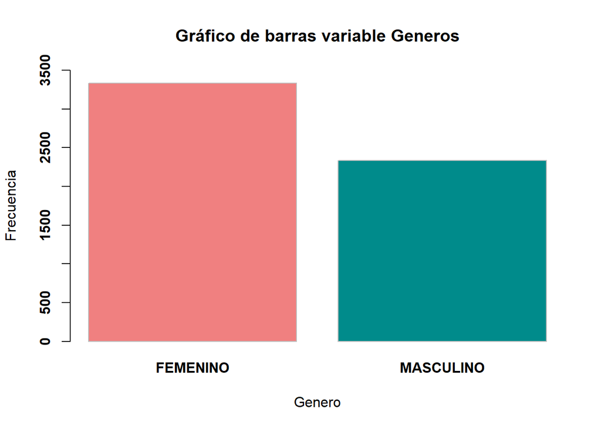

Se observa que el 58.8% de los estudiantes entrevistados son de sexo Femenino y el 41.2% son de sexo Masculino.

## Provincia

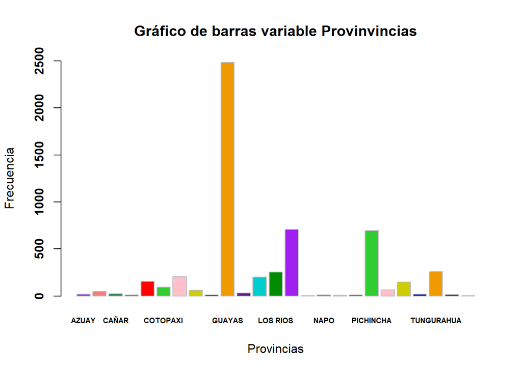

Se observa que la mayoría de los estudiantes entrevistados sin de la provincia del Guayas con un 44.8%.

## Sostenimiento

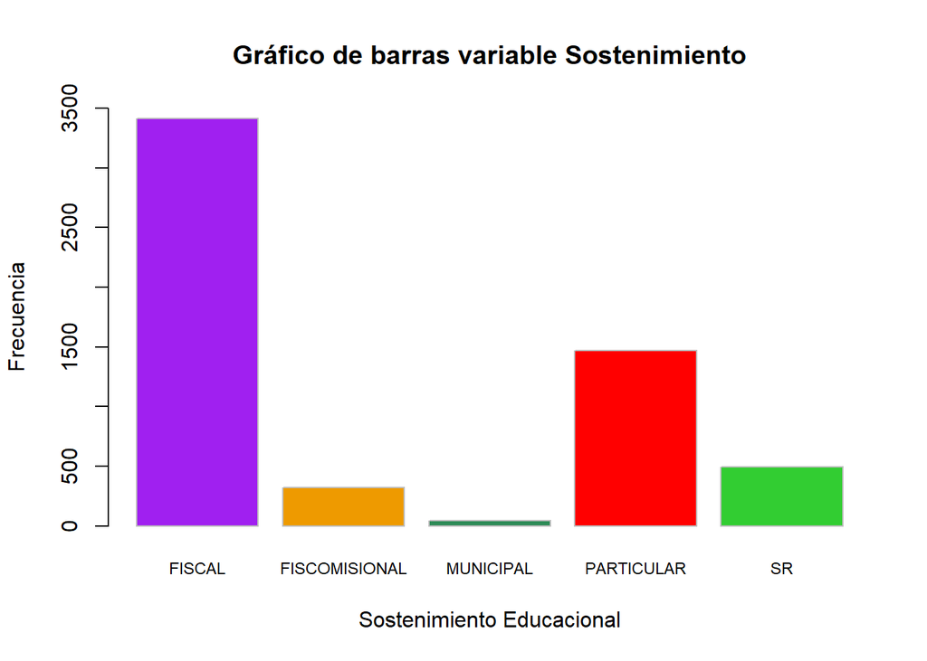

El 25.6% de las instituciones son particulares, el 59.5% pertenecen a instituciones fiscales, el y 5.6% son fiscomisionales.

## Preparacion para el examen

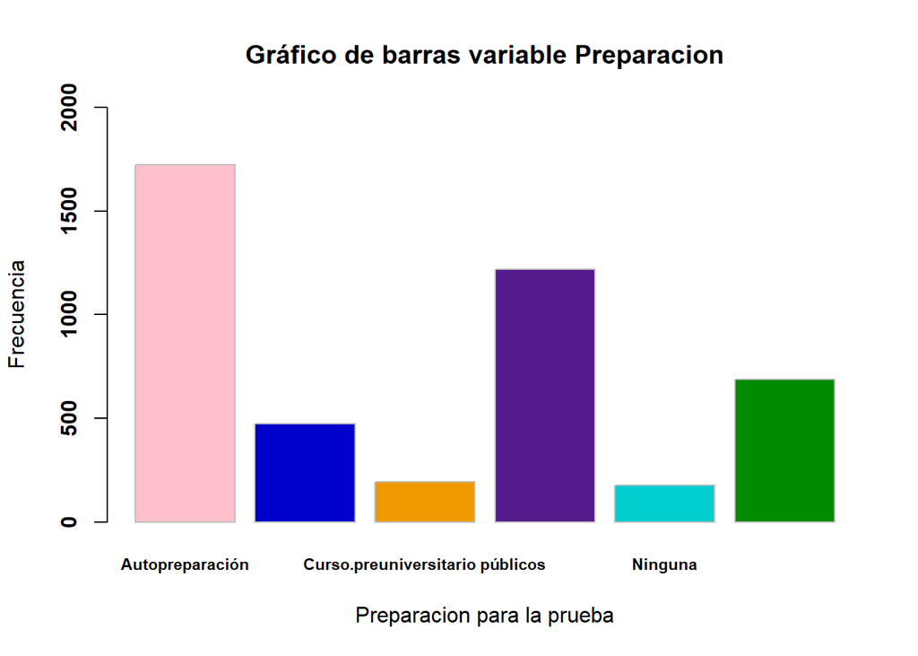

Se observa que la mayoría de los estudiantes se auto prepararon para rendir el examen, con un 38 .4%

## Numero de aciertos

**Resumen de la variable:**

```
##    Min. 1st Qu.  Median    Mean 3rd Qu.    Max.
##    0.00   24.00   29.00   29.41   35.00   75.00
```

**Rango Intercuantilico:**

```
## [1] 11
```

**Moda:**

```
## [1] 28
```

**Varianza:**

```
## [1] 83.45906
```

**Desviacion Estandar:**

```
## [1] 9.135593
```

**Sesgo:**

```
## [1] -0.1791222
```

**Kurtosis:**

```
## [1] 1.220987
```

Se muestra un resumen de las principales estadísticas descriptivas sobre el número de aciertos que obtuvieron los estudiantes en la prueba, tanto medidas de tendencia central como de dispersión. La misma indica que, por ejemplo, los estudiantes obtuvieron, en promedio, 29.41/80 aciertos, con una desviación típica de 9.14 en promedio alrededor de la media. Por otro lado, el menor número de aciertos registrado es de 0 y el mayor, de 75, mientras que el 50% de los mismos son menores a 29. Por último, el 50% de las mediciones centrales se concentran entre 24 y 35, asimismo, los registros de numero de aciertos presentan un sesgo de -0.18, los que corrobora lo discutido a partir del histograma. Estos últimos datos se pueden ver mejor en el diagrama de caja respectivo.

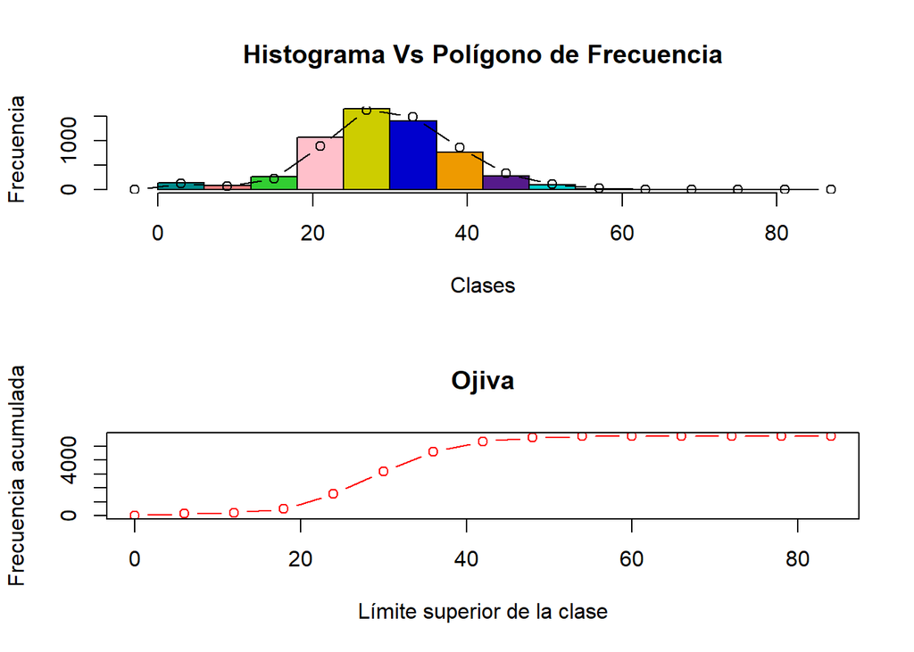

Tabla de Frecuencias

[output not shown]

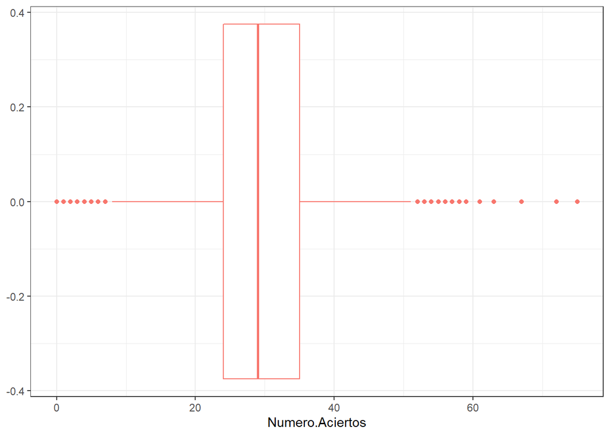

# **Analisis Estadistico Bivariante**

Para nuestro analisis bivariante hemos relacionado algunas de las variables que se presentan a continuacion: De nuestra tabla $datosu$ queremos saber la relacion que existe entre la variable numero de aciertos y el nivel educativo del padre. ## Aciertos vs Nivel de educacion del padre

[interactive chart not shown]

Podemos observar que en la variable aciertos los estudiantes que tuvieron mayor porcentaje de pruebas rendidas con calificaciones mala,regular o buena son aquellos que tienen padres que solo han tenido un nivel de educacion de 4to a 6to curso. Por lo tanto, podemos decir que el nivel de educacion que tenga el padre no influye como tal en los estudiantes.

## Aciertos vs Provincia en la que Residen

Con el fin de obtener informacion sobre cual fue la povincia con mas estudiantes que rindieron la prueba de ser bachiller hemos decidido seleccionar dos variables para obtener mayor informacion de la misma.

[interactive chart not shown]

En cuanto a la provincia en la cual residen, podemos ver que la mayor cantidad de estudiantes que rindieron la prueba es en la provincia del Guayas, seguido de Manabi y Pichincha.

## Aciertos vs Etnia

Quisimos analizar tambien cuantos estudiantes por etnia rindieron la prueba y sus porcentajes de aciertos.

[interactive chart not shown]

El diagrama nos refleja que hubieron mas estudiantes mestizos que obtuvieron una puntaje regular de aciertos en la prueba. Casi no se registran estudiantes que obtuvieron un puntaje muy bueno por raza. La mayoria de estudiantes registrados se consideran de una etnia mestiza.

# **Estadistica Inferencial**

## Bondad de ajuste

Realizamos un test de Kolmogorov para determinar si los datos provenian de una distribución normal.

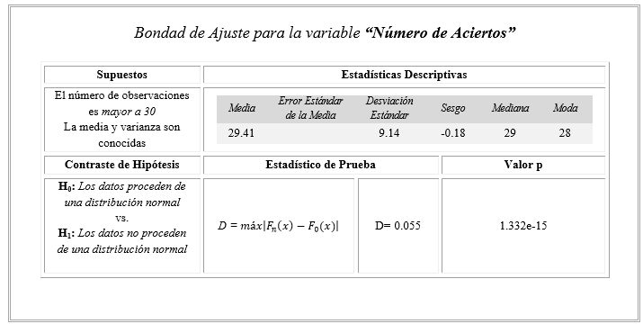

Se puede concluir que los datos no provienen de una distribucion normal dado que nuestro valor p es menor a nuestra significancia $\alpha=0.05$, por lo tanto, se rechaza la hipotesis nula.

## Pruebas de Hipotesis

### **Prueba de Hipotesis para una Media**

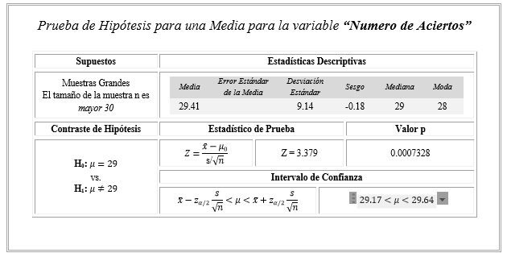

como el valor de p que resulto es menor al nivel de significancia que es $\alpha=0.05$, podemos rechazar la hipotesis nula. Por lo tanto la media del número de aciertos es diferente de 29.

**Prueba de Hipotesis para proporción**

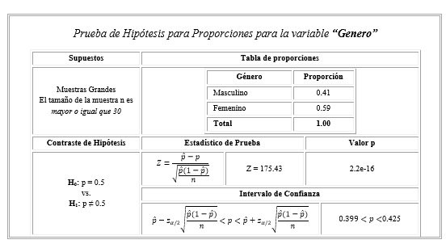

Podemos rechazar la hipotesis nula a favor de la alternativa ya que el valor p es menor al nivel de significancia $\alpha=0.05$. Concluimos asi que las proporciones para cada genero son diferentes.

## Analisis de Contingencia

*H0: Las variables son independientes* *vs.* *H1: son dependientes*

## Prueba de independencia para las variables “preparacion” y “Número de Aciertos”

Tabla de Contigencia

|  | Curso preuniversitario privado | Curso.preuniversitario públicos | En tu colegio | Ninguna | Plataforma Ser Bachiller |
| --- | --- | --- | --- | --- | --- |
| Malo(0-20) | 51 | 21 | 170 | 28 | 91 |
| Regular(21-40) | 338 | 149 | 938 | 136 | 554 |
| Bueno(41-60) | 84 | 25 | 107 | 13 | 44 |
| Muy bueno(61-80) | 1 | 0 | 4 | 0 | 0 |

**Prueba Chi- cuadrado:**

```
##
##  Pearson's Chi-squared test
##
## data:  tc1[, -1]
## X-squared = 53.113, df = 12, p-value = 3.933e-07
```

Con este test podemos rechazar la hipotesis nula dado que nuestro valor p es menor a nuestro nivel de significancia $\alpha=0.05$. Por lo tanto podemos concluir que las variables son dependientes.Es decir, que la pareparacion del estudiante para la prueba influye en el numero de aciertos en la misma.

## Prueba de independencia para las variables “Sostenimiento” y “Número de Aciertos”

Tabla de Contigencia

|  | FISCAL | FISCOMISIONAL | MUNICIPAL | PARTICULAR |
| --- | --- | --- | --- | --- |
| Malo(0-20) | 426 | 31 | 2 | 201 |
| Regular(21-40) | 2692 | 242 | 31 | 1069 |
| Bueno(41-60) | 291 | 47 | 9 | 193 |
| Muy bueno(61-80) | 3 | 1 | 0 | 4 |

**Prueba Chi- cuadrado:**

```r
chisq.test(tc2[,-5])
```

```
##
##  Pearson's Chi-squared test
##
## data:  tc2[, -5]
## X-squared = 46.565, df = 9, p-value = 4.729e-07
```

Con este test podemos rechazar la hipotesis nula dado que nuestro valor p es menor a nuestro nivel de significancia $\alpha=0.05$. Por lo tanto podemos concluir que las variables son dependientes.Es decir, que el tipo de sostenimiento educativo al que pertenecen los estudiantes influyen en el numero de aciertos en la prueba Ser Bachiller.

# **Analisis Multivariante**

## Analisis de Correspondencia

## AC: Sostenimiento y Preparación

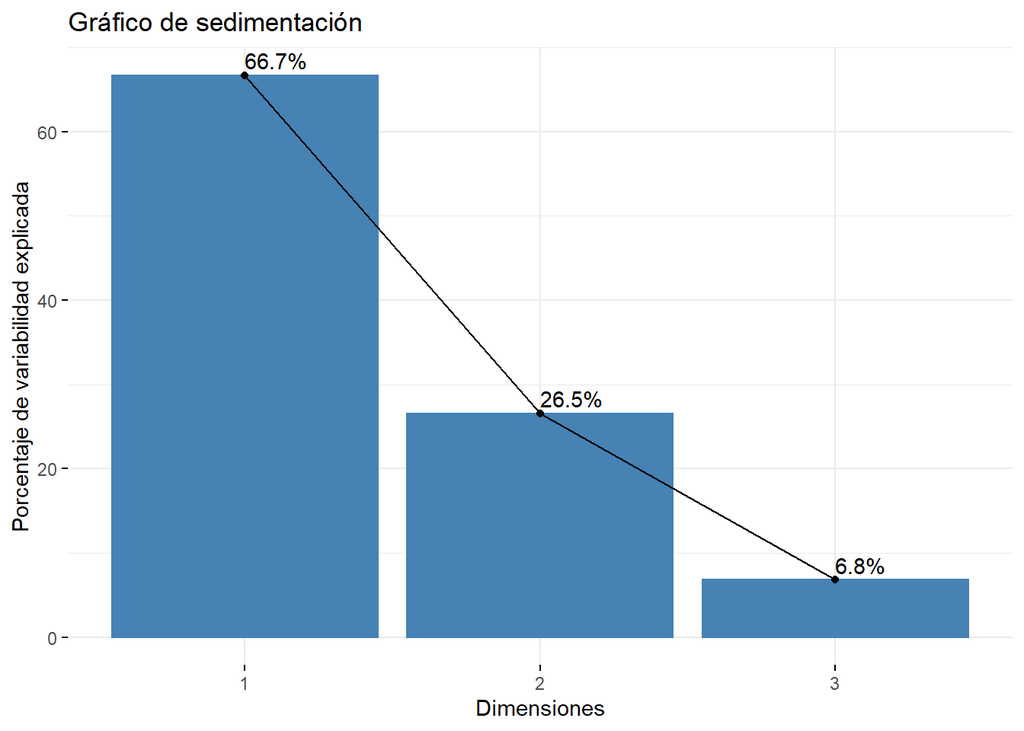

Se observa que con las dimensiones 1(66.7%) y 2(26.5%) se captura un total de 93.2% de varianza total, lo cual es suficiente para realizar nuestro analisis.

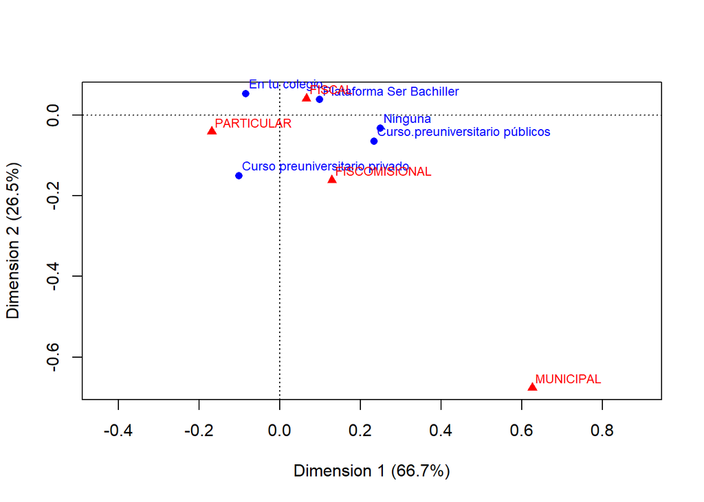

• Se observa que la dimension 1 discrimita el sostenimiento educativo y la dimension 2 discrimina la preparacion que tuvo el estudiante para rendir la prueba.

• Los estudiantes quienes pertenecen a un colegio de sostenimiento fiscal se prepararon en su colegio y en la plataforma de Ser bachiller.

• Se observa como hay una ligera agrupacion entre los estudiantes que pertenecen a un colegio particular con una preparacion en un curso pre universitario privado.

• Se observa que los estudiantes que pertenecen a un colegio de sostenimiento Fiscomisional se prepararon en un curso pre universitario publico.

Se puede concluir una evidente asociacion con respecto a los estudiantes que, gracias a sus padres, disponen un poco mas de economia para tener una preparacion pagada para rendir la prueba Ser Bachiller.

## Ac: Etnia y Sostenimiento

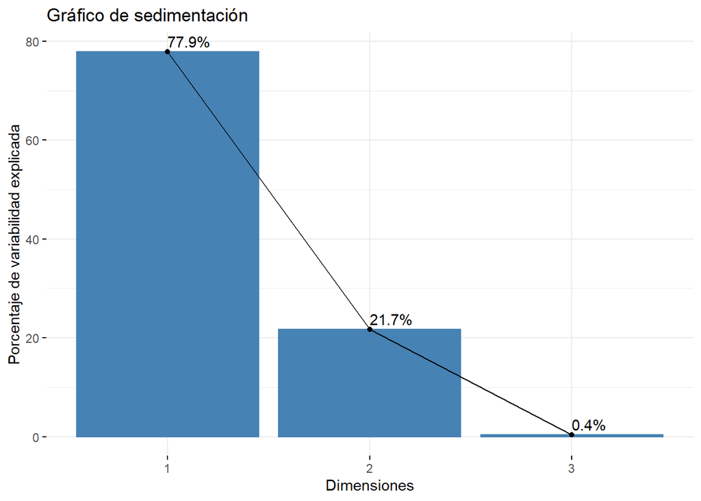

Se observa que con las dimensiones 1(77.9%) y 2(21.7%) se captura un total de 99.6% de varianza total, lo cual es suficiente para realizar nuestro analisis.

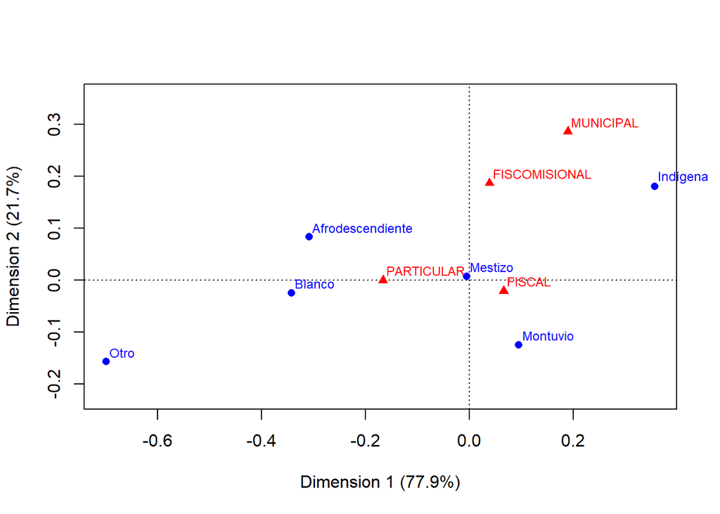

• Se observa que la dimension 1 discrimita el sostenimiento educativo y la dimension 2 discrimina la etnia del estudiante.

• Los estudiantes quienes pertenecen a un colegio de sostenimiento fiscal se asocian con una etnia montubia y mestiza.

• Se observa como hay una ligera agrupacion entre los estudiantes que pertenecen a un colegio particular con una etnia afrodesenciente, mestizo y blanco.

• Se observa que los estudiantes que pertenecen a un colegio de sostenimiento Fiscomisional y municipal se asocia ligeramente con una etnia indigena.

Se puede concluir una evidente asociacion con respecto a las etnias de los estudiantes con el sostenimiento educativo, esto se debe a que por lo general la cultura y etnia del estudiante influye en donde habita y esto se ve reflejado tambien en el tipo de sostenimiento educativo del colegio al que pertenecen al momento de rendir la prueba

## AC: Aciertos y Sostenimiento

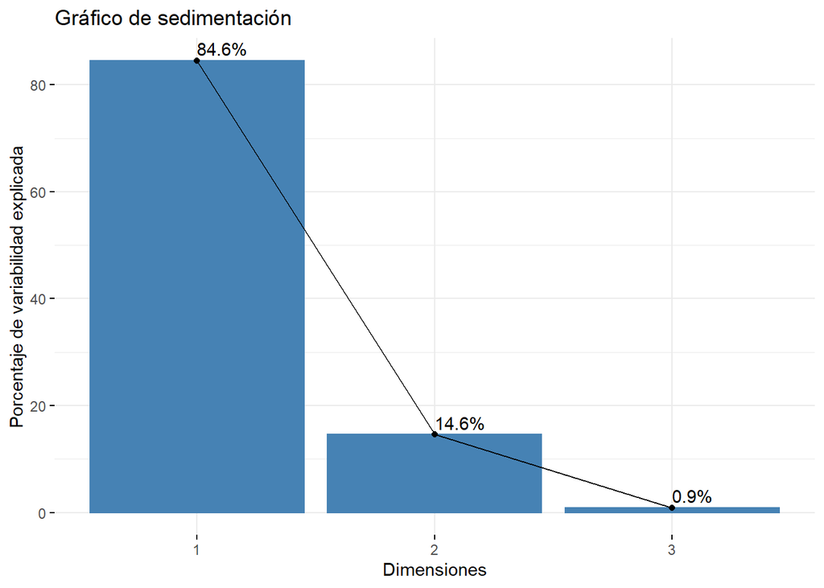

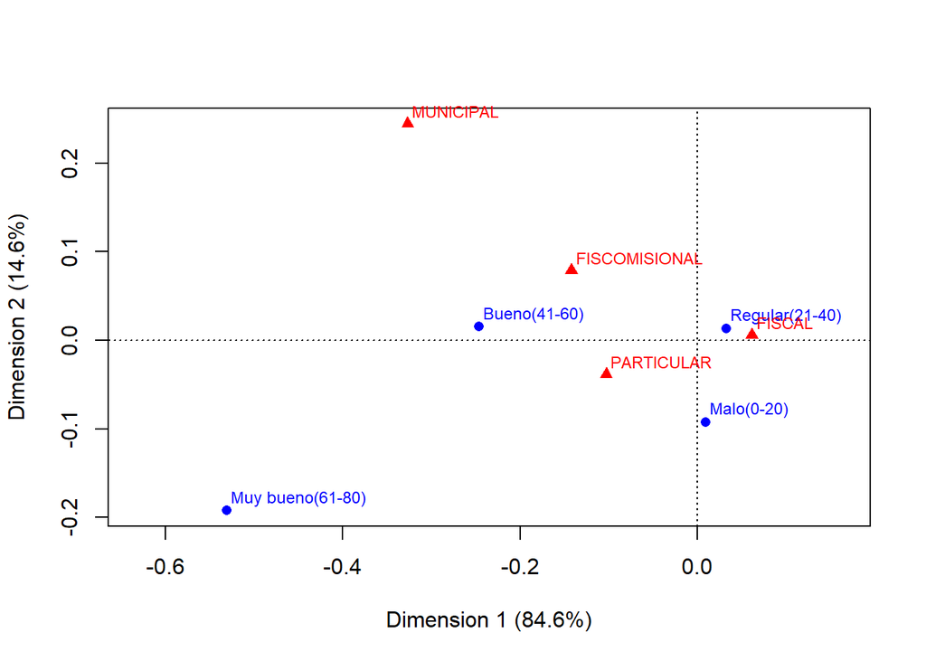

## Analisis de Correspondencia Multiple

Para el analisis de correspondencia multiple decidimos trabajar con los aciertos de los estudiantes en los distintos campos y sub campos de conocimiento en el examen. Para asi poder tener un enfoque visual de las respectivas agrupaciones y su variabilidad en las distintas dimensiones presentadas.

```
## Class: acm dudi
## Call: dudi.acm(df = aciertos_m, scannf = F, nf = 5)
##
## Total inertia: 10.33
##
## Eigenvalues:
##     Ax1     Ax2     Ax3     Ax4     Ax5
##  0.8425  0.8013  0.6853  0.6213  0.5223
##
## Projected inertia (%):
##     Ax1     Ax2     Ax3     Ax4     Ax5
##   8.153   7.754   6.632   6.013   5.054
##
## Cumulative projected inertia (%):
##     Ax1   Ax1:2   Ax1:3   Ax1:4   Ax1:5
##   8.153  15.907  22.540  28.553  33.607
##
## (Only 5 dimensions (out of 26) are shown)
```

El resumen nos indica que las primeras seis dimensiones aportan mas variabilidad en comparacion a las otras dimensines de nuestro modelo de analisis de correspondencia. Aportando un total de 38.26% de varianza.

### Grafico de sedimentacion para ver cuantas dimensiones son factibles

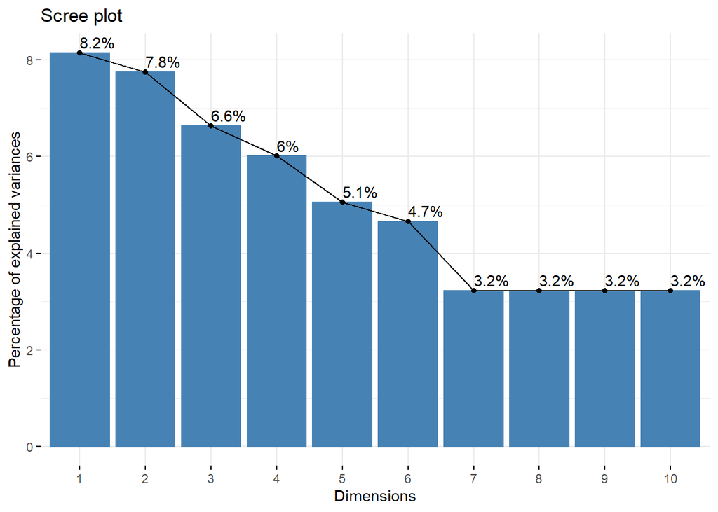

Se observa que en la sexta dimnension ya no ganamos mucha varianza explicada, sin embargo, a partir de la septima dimension la curva se aplana,es decir, que capturan el mismo porcentaje de varianza explicada.

### Contribucion de las variables a la dimension 1

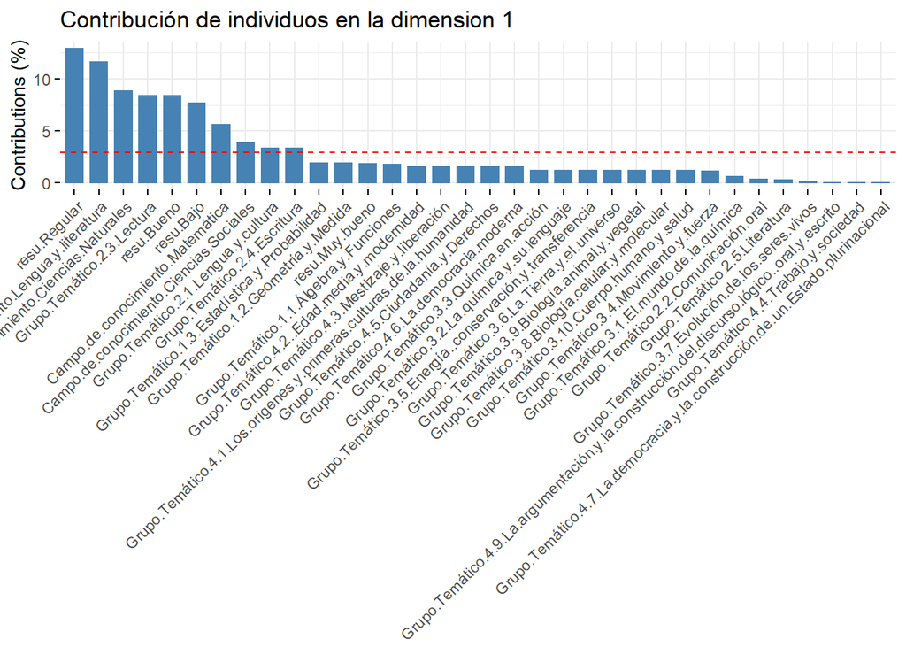

### Contribucion de las variables a la dimension 2

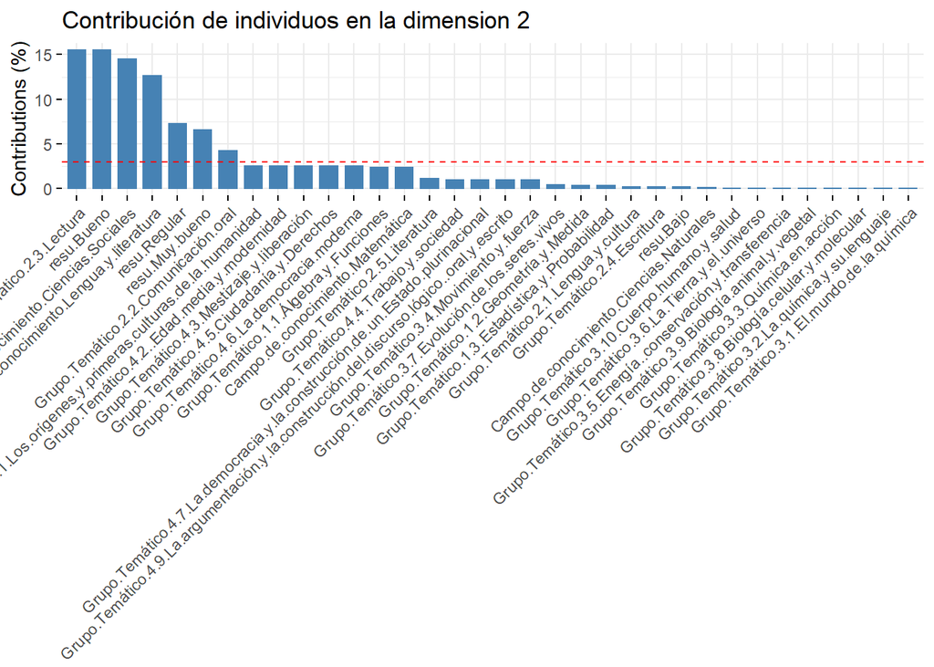

Se observa una mayor contribucion del nivel Lectura del factor grupo tematico del campo de conocimiento de Lengua y literatura, y ademas, los estudiantes que obtuvieron un buen numero de aciertos son los que aportan de igual manera a la dimension 2, cuya aportacion es poco mayor al 15%.  
El factor de Campo de conocimiento Ciencias sociales sigue con una contribucion poco menor a $15%$ a la dimension 2.

### Contribucion de las variables a la dimension 3

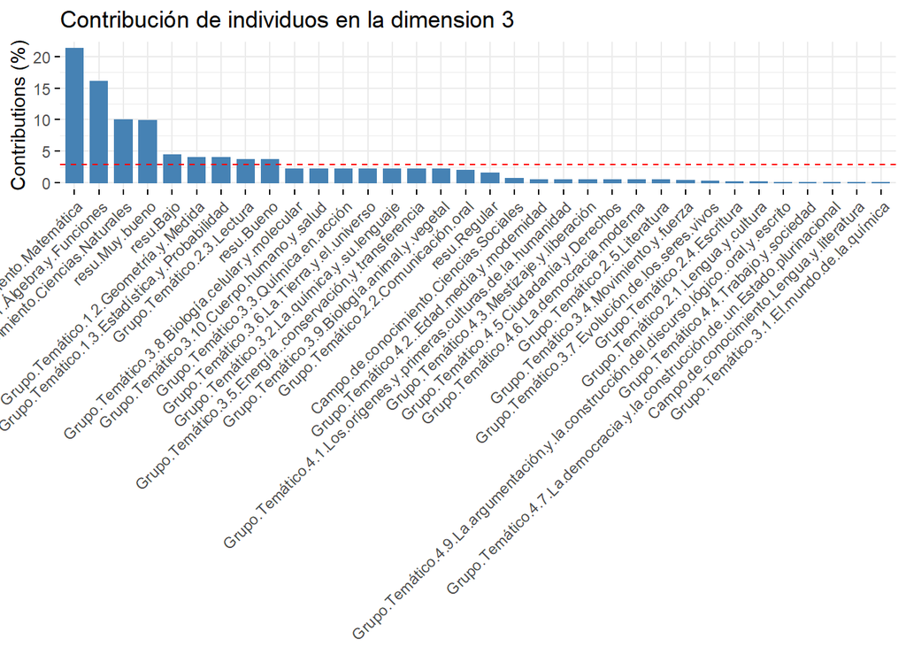

Se observa una mayor contribucion del nivel Matematica del factor campo de conocimiento el cual es muy cercano al 21% para la dimension 3. El nivel de Algebra y funciones del factor Grupo tematico sigue con una contribucion poco mayor a 15% a la dimension 3.

### Representacion simultanea de los individuos

**Con dimesiones 1 y 2** ***

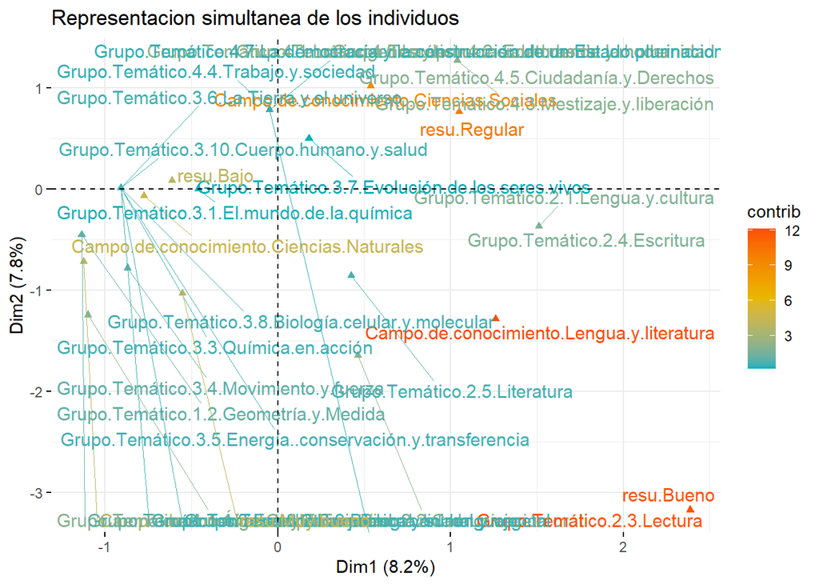

Teniendo en cuenta que la primera dimension discrimina a la variable Numero de aciertos (resu) y la segunda dimension discrimina al Campo de conocimiento, se concluye:

• Se observa como se agrupan el grupo tematico Lectura con buenos resultados

• Se observa que el campo de conocimiento Matematica esta agrupado con resultados muy buenos juntos con el grupo tematico Movimiento y fuerza, Algebra y ecuaciones y Estadistica y Probabilidad.

• El campo de conocimiento de Ciencias Naturales esta asociado con Bajos resultados de aciertos y con varios grupos tematicos de este campo.

**Con dimesiones 1 y 3** ***

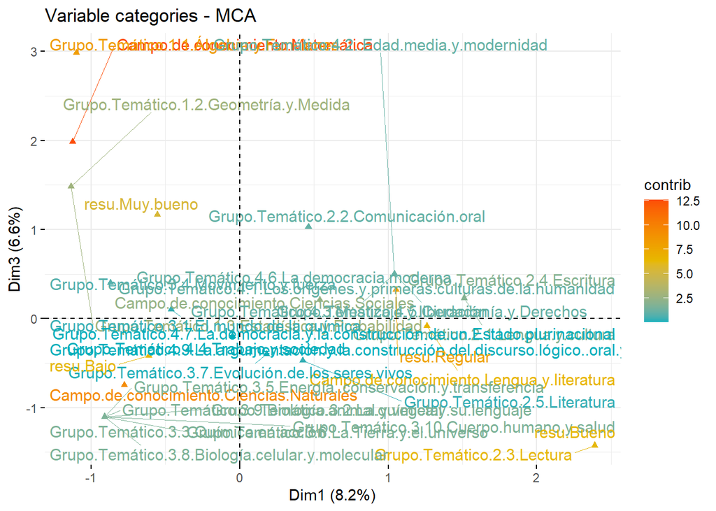

Teniendo en cuenta que la primera dimension discrimina a la variable Numero de aciertos (resu) y la tercera dimension discrimina al grupo tematico, se concluye:

• Se observa que los esrudiantes obtuvieron un resultado de aciertos regular en los Grupos tematicos: comunicacion oral, ciudadania y derechos, mestizaje, escritura, lengua y cultura, entre otros.

• Se observa una lejania en comparacion a la grafica aanterior del nivel muy bueno de la variable Numero de aciertos (resu) con el campo de conocimiento de matematicas y otros grupos tematicos.

**Con dimesiones 2 y 3** ***

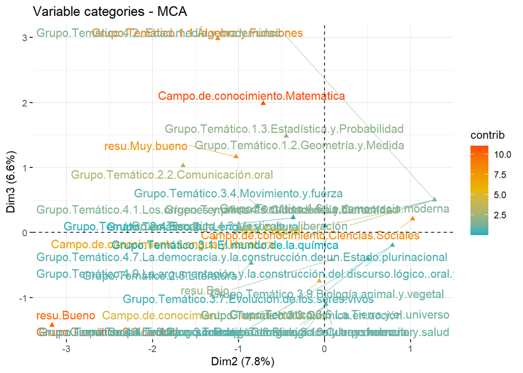

Teniendo en cuenta que la segunda dimension discrimina a la variable Campo de conocimiento y la tercera dimension discrimina al grupo tematico, se concluye:

• Se observa una agrupacion de resultados bajos con el campo tematico de Literatura, evolucione de los seres vivos, trabajo y sociedad, entre otros.

• Se observa una agrupacion de resultados regulares con el campo tematico de mestizaje y liberacion,edad media y modernidad, entre otros, todos pertenecientes al campo de conocimiento de Ciencias Sociales.

### Representacin simultanea reducida

Y también se puede seleccionar los individuos más importantes y las categorías más importantes (10 en este caso).

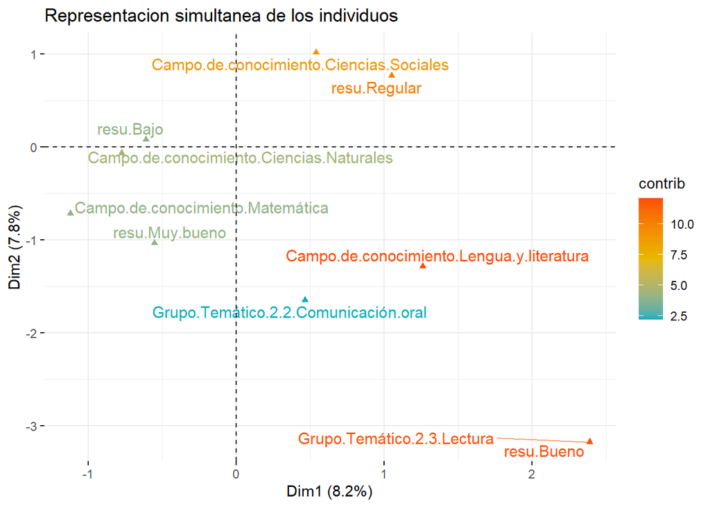

Teniendo en cuenta que la primera dimension discrimina a la variable Numero de aciertos (resu) y la segunda dimension discrimina al Campo de conocimiento, se concluye en base a la vista generalizada obtenida que:

• Se asocia con resultados bajos y el campo de conocimiento de Ciencias naturales.

• Se asocia el grupo tematico Lectura con resultados buenos obtenidos por los estudiantes en la prueba.

• Se asocia el campo de conocimiento matematica con los resultados muy buenos obtenidos por los estudiantes.

• Se asocia el campo de conocimiento Ciencias Sociales con los resultados regulares obtenidos por los estudiantes.

### Conclusiones Generales

• Los estudiantes obtubieron buenos resultados de aciertos en el grupo tematico de Lectura.

• Los estudiantes obtubieron malos resultados de aciertos en varios grupos tematicos de Ciencias Naturales lo que nos da un indicio de que los estudiantes tuvieron falencias en esta area o campo de conocimiento.

• Los estudiantes obtuvieron resultados regulares en el campo de conocimiento o area de ciencias sociales en general. Asi mismo se observa un acercamiento por parte de los grupos tematicos de Lengua y cultura y escritura como tal.

• Los estudiantes obtuvieron muy buenos resultados en el campo de conocimiento Matematica junto con el grupo tematico Movimiento y fuerza, Algebra y ecuaciones y Estadistica y Probabilidad respectivos a esta area.

• Los estudiantes obtuvieron un resultado de aciertos regular en los Grupos tematicos: comunicacion oral, ciudadania y derechos, mestizaje, escritura, lengua y cultura, entre otros.